# Clustering of Properties Sold in New York City

Achmad Gunar Saadi

September 17, 2018

# 1 Introduction

## 1.1 Objectives

**Project: Clustering of Properties Sold in New York City**

Using two unsupervised learning algorithms, PCA and K-Means, and produce a R markdown document where you demonstrate an exercise of *clustering* and *dimensionality reduction* on the `nyc.csv` dataset.

The steps must be able to explain how you choose k for K-Means clustering, or how you choose to retain n number of dimensions for PCA from the original data.

## 1.2 Data Explanation

The dataset used is `nyc.csv`. This dataset is a record about properties sold (apartment, etc) in New York City market over a 12-month period from September 2016 to September 2017. As the reference check link https://www.kaggle.com/new-york-city/nyc-property-sales.  
The dataset is originally from New York City Department of Finance and made available by City of New York which contains 22 variables as following:

**X**: ID number of customer(numeric)  
**BOROUGH**: A digit code for the borough the property is located in; (1=Manhattan, 2=Bronx, 3=Brooklyn, 4=Queens, and 5=Staten Island) (numeric)  
**NEIGHBORHOOD**: The neighborhood name (string)  
**BUILDING.CLASS.CATEGORY**: Category class of the property (string)  
**TAX.CLASS.AT.PRESENT, TAX.CLASS.AT.TIME.OF.SALE, BLOCK, LOT**: The combination of borough, block, and lot forms a unique key for property in New York City (numeric)  
**EASE.MENT**:An easement is a right, such as a right of way, which allows an entity to make limited use of another’s real property (string)  
**BUILDING.CLASS.AT.PRESENT, BUILDING.CLASS.AT.TIME.OF.SALE**: The type of building at various points in time (string)  
**ADDRESS**: Street address of the property (string)  
**APARTMENT.NUMBER**: Apartment number if applicable (string)  
**ZIP.CODE**: The property’s postal code (numeric)  
**RESIDENTIAL.UNITS**: The number of residential units at the listed property (numeric)  
**COMMERCIAL.UNITS**: The number of commercial units at the listed property (numeric)  
**TOTAL.UNITS**: Equal to residential units added by commercial units (numeric)  
**LAND.SQUARE.FEET**: The land area of the property listed in square feet (numeric)  
**GROSS.SQUARE.FEET**: The total area of all the floors of a building as measured from the exterior surfaces of the outside walls of the building, including the land area and space within any building or structure on the property (numeric)  
**YEAR.BUILT**: Year the property was built (numeric)  
**SALE.PRICE**: Price paid for the property (numeric)  
**SALE.DATE**: Date the property sold (date)

## 1.3 Read and understand the Dataset

This is how the data look like (I only display the first 6 data) and including the 22 variables mentioned before and 84548 observations.

```r
prop <- read.csv("./nyc.csv")
head(prop)
```

```
##   X BOROUGH  NEIGHBORHOOD                     BUILDING.CLASS.CATEGORY
## 1 4       1 ALPHABET CITY 07 RENTALS - WALKUP APARTMENTS
## 2 5       1 ALPHABET CITY 07 RENTALS - WALKUP APARTMENTS
## 3 6       1 ALPHABET CITY 07 RENTALS - WALKUP APARTMENTS
## 4 7       1 ALPHABET CITY 07 RENTALS - WALKUP APARTMENTS
## 5 8       1 ALPHABET CITY 07 RENTALS - WALKUP APARTMENTS
## 6 9       1 ALPHABET CITY 07 RENTALS - WALKUP APARTMENTS
##   TAX.CLASS.AT.PRESENT BLOCK LOT EASE.MENT BUILDING.CLASS.AT.PRESENT
## 1                   2A   392   6        NA                        C2
## 2                    2   399  26        NA                        C7
## 3                    2   399  39        NA                        C7
## 4                   2B   402  21        NA                        C4
## 5                   2A   404  55        NA                        C2
## 6                    2   405  16        NA                        C4
##                  ADDRESS APARTMENT.NUMBER ZIP.CODE RESIDENTIAL.UNITS
```

[output cut: 27 more lines]

The dataset comprises integer and factor data-type from str().

# 2 Exploring the Data

## 2.1 Quick Look the data

```r
summary(prop)
```

```
##        X            BOROUGH                       NEIGHBORHOOD
##  Min.   :    4   Min.   :1.000   FLUSHING-NORTH         : 3068
##  1st Qu.: 4231   1st Qu.:2.000   UPPER EAST SIDE (59-79): 1736
##  Median : 8942   Median :3.000   UPPER EAST SIDE (79-96): 1590
##  Mean   :10344   Mean   :2.999   UPPER WEST SIDE (59-79): 1439
##  3rd Qu.:15987   3rd Qu.:4.000   BEDFORD STUYVESANT     : 1436
##  Max.   :26739   Max.   :5.000   MIDTOWN EAST           : 1418
##                                  (Other)                :73861
##                                 BUILDING.CLASS.CATEGORY
##  01 ONE FAMILY DWELLINGS                    :18235
##  02 TWO FAMILY DWELLINGS                    :15828
##  13 CONDOS - ELEVATOR APARTMENTS            :12989
##  10 COOPS - ELEVATOR APARTMENTS             :12902
##  03 THREE FAMILY DWELLINGS                  : 4384
##  07 RENTALS - WALKUP APARTMENTS             : 3466
##  (Other)                                    :16744
##  TAX.CLASS.AT.PRESENT     BLOCK            LOT         EASE.MENT
##  1      :38633        Min.   :    1   Min.   :   1.0   Mode:logical
##  2      :30919        1st Qu.: 1323   1st Qu.:  22.0   NA's:84548
##  4      : 6140        Median : 3311   Median :  50.0
##  2A     : 2521        Mean   : 4237   Mean   : 376.2
##  2C     : 1915        3rd Qu.: 6281   3rd Qu.:1001.0
##  1A     : 1444        Max.   :16322   Max.   :9106.0
##  (Other): 2976
##  BUILDING.CLASS.AT.PRESENT                   ADDRESS      APARTMENT.NUMBER
##  D4     :12663             131-05 40TH   ROAD    :  210          :65496
##  R4     :12482             429 KENT AVENUE       :  158   4      :  298
##  A1     : 6753             169 WEST 95TH   STREET:  153   3A     :  295
##  A5     : 5683             131-03 40TH   ROAD    :  147   2      :  275
##  B2     : 4923             265 STATE STREET      :  127   3B     :  275
##  B1     : 4749             550 VANDERBILT AVENUE :  126   2B     :  272
##  (Other):37295             (Other)               :83627   (Other):17637
##     ZIP.CODE     RESIDENTIAL.UNITS  COMMERCIAL.UNITS     TOTAL.UNITS
##  Min.   :    0   Min.   :   0.000   Min.   :   0.0000   Min.   :   0.000
##  1st Qu.:10305   1st Qu.:   0.000   1st Qu.:   0.0000   1st Qu.:   1.000
##  Median :11209   Median :   1.000   Median :   0.0000   Median :   1.000
##  Mean   :10732   Mean   :   2.025   Mean   :   0.1936   Mean   :   2.249
##  3rd Qu.:11357   3rd Qu.:   2.000   3rd Qu.:   0.0000   3rd Qu.:   2.000
##  Max.   :11694   Max.   :1844.000   Max.   :2261.0000   Max.   :2261.000
##
```

[output cut: 9 more lines]

```
##  Min.   :1.000             R4     :12989                   -     :14561
##  1st Qu.:1.000             D4     :12666                  0      :10228
##  Median :2.000             A1     : 6751                  10     :  766
##  Mean   :1.657             A5     : 5671                  450000 :  427
##  3rd Qu.:2.000             B2     : 4918                  550000 :  416
##  Max.   :4.000             B1     : 4747                  650000 :  414
##                            (Other):36806                  (Other):57736
##                SALE.DATE
##  2017-06-29 00:00:00:  544
##  2017-06-15 00:00:00:  530
##  2016-12-22 00:00:00:  527
##  2017-05-25 00:00:00:  511
##  2016-10-06 00:00:00:  508
##  2016-10-28 00:00:00:  493
##  (Other)            :81435
```

```r
anyNA(prop)
```

```
## [1] TRUE
```

From summary of the dataset above, there is empty variable in the data. Hence, it is necessary to omit this variable.

```r
omitted <- c("EASE.MENT")
prop<-prop[ , !(names(prop) %in% omitted)]
anyNA(prop)
```

```
## [1] FALSE
```

```r
str(prop)
```

```
## 'data.frame':    84548 obs. of  21 variables:
##  $ X                             : int  4 5 6 7 8 9 10 11 12 13 ...
##  $ BOROUGH                       : int  1 1 1 1 1 1 1 1 1 1 ...
##  $ NEIGHBORHOOD                  : Factor w/ 254 levels "AIRPORT LA GUARDIA",..: 2 2 2 2 2 2 2 2 2 2 ...
##  $ BUILDING.CLASS.CATEGORY       : Factor w/ 47 levels "01 ONE FAMILY DWELLINGS                    ",..: 7 7 7 7 7 7 7 7 8 8 ...
##  $ TAX.CLASS.AT.PRESENT          : Factor w/ 11 levels " ","1","1A","1B",..: 7 6 6 8 7 6 8 6 6 6 ...
##  $ BLOCK                         : int  392 399 399 402 404 405 406 407 379 387 ...
##  $ LOT                           : int  6 26 39 21 55 16 32 18 34 153 ...
##  $ BUILDING.CLASS.AT.PRESENT     : Factor w/ 167 levels " ","A0","A1",..: 17 22 22 19 17 19 19 22 31 35 ...
##  $ ADDRESS                       : Factor w/ 67563 levels "****** 95TH   STREET",..: 14951 28602 22213 15133 35432 49353 24812 49575 11712 53854 ...
##  $ APARTMENT.NUMBER              : Factor w/ 3989 levels " ","#4","#PHC",..: 1 1 1 1 1 1 1 1 1 1 ...
##  $ ZIP.CODE                      : int  10009 10009 10009 10009 10009 10009 10009 10009 10009 10009 ...
##  $ RESIDENTIAL.UNITS             : int  5 28 16 10 6 20 8 44 15 24 ...
##  $ COMMERCIAL.UNITS              : int  0 3 1 0 0 0 0 2 0 0 ...
##  $ TOTAL.UNITS                   : int  5 31 17 10 6 20 8 46 15 24 ...
##  $ LAND.SQUARE.FEET              : Factor w/ 6062 levels " -  ","0","100",..: 1070 4120 1851 1920 2039 2293 1242 4488 928 4026 ...
##  $ GROSS.SQUARE.FEET             : Factor w/ 5691 levels " -  ","0","100",..: 4845 1412 5188 4951 4083 5620 3857 1720 5508 1389 ...
##  $ YEAR.BUILT                    : int  1900 1900 1900 1913 1900 1900 1920 1900 1920 1920 ...
##  $ TAX.CLASS.AT.TIME.OF.SALE     : int  2 2 2 2 2 2 2 2 2 2 ...
##  $ BUILDING.CLASS.AT.TIME.OF.SALE: Factor w/ 166 levels "A0","A1","A2",..: 16 21 21 18 16 18 18 21 30 34 ...
##  $ SALE.PRICE                    : Factor w/ 10008 levels " -  ","0","1",..: 7868 1 1 5400 8867 1 4458 1 1 1879 ...
##  $ SALE.DATE                     : Factor w/ 364 levels "2016-09-01 00:00:00",..: 321 105 100 23 78 322 23 322 292 68 ...
```

As can be seen, the dataset now has no empty variables. Therefore there are total 21 variables remain.  
Principally, in this assignment I’d like to combine PCA and K-means algorithms to tackle problems in clustering of properties sold in New York City using `nyc.csv`. We are gonna simplify the dimensions assessed using PCA (Principle Component Analysis) so that easier to be visualized in a diagram. The rest using K-means algorithm to cluster the properties. This method believed leads to better results than merely using K-means alone.

# 3 Processing

## 3.1 Pre-processing

### 3.1.1 Data Modification

As the data contain many variables. To make it compact, convert all remain variables into integer and also exclude the unnecessary variables.

```r
library(dplyr)
propt <- prop %>%
  mutate(RESIDENTIAL.UNITS= as.integer(RESIDENTIAL.UNITS),
         COMMERCIAL.UNITS= as.integer(COMMERCIAL.UNITS),
         TOTAL.UNITS= as.integer(TOTAL.UNITS),
         LAND.SQUARE.FEET = as.integer(LAND.SQUARE.FEET),
         GROSS.SQUARE.FEET = as.integer(GROSS.SQUARE.FEET),
         YEAR.BUILT= as.integer(YEAR.BUILT),
         SALE.PRICE = as.integer(SALE.PRICE)
         ) %>%
  select_if(is.integer) %>%
  select(-c(X, BOROUGH, BLOCK, LOT, ZIP.CODE, TAX.CLASS.AT.TIME.OF.SALE)) %>%
  filter(complete.cases(.))
summary(propt)
```

```
##  RESIDENTIAL.UNITS  COMMERCIAL.UNITS     TOTAL.UNITS
##  Min.   :   0.000   Min.   :   0.0000   Min.   :   0.000
##  1st Qu.:   0.000   1st Qu.:   0.0000   1st Qu.:   1.000
##  Median :   1.000   Median :   0.0000   Median :   1.000
##  Mean   :   2.025   Mean   :   0.1936   Mean   :   2.249
##  3rd Qu.:   2.000   3rd Qu.:   0.0000   3rd Qu.:   2.000
##  Max.   :1844.000   Max.   :2261.0000   Max.   :2261.000
##  LAND.SQUARE.FEET GROSS.SQUARE.FEET   YEAR.BUILT     SALE.PRICE
##  Min.   :   1     Min.   :   1      Min.   :   0   Min.   :    1
##  1st Qu.:   1     1st Qu.:   1      1st Qu.:1920   1st Qu.:    2
##  Median :1209     Median : 315      Median :1940   Median : 3316
##  Mean   :1420     Mean   :1064      Mean   :1789   Mean   : 3711
##  3rd Qu.:2314     3rd Qu.:1791      3rd Qu.:1965   3rd Qu.: 6780
##  Max.   :6062     Max.   :5691      Max.   :2017   Max.   :10008
```

### 3.1.2 Scaling the dataset

From the previous section, the summary of the data tell that there are different various range of each variables. The difference can be problematic for K-means clustering algorithm. It is because, the result will tend to affected by variables with higher range value. To make the weighting fairer, it is necessary scale the dataset. In this case, we use z-value scaling.

```r
prop_z <- scale(propt, center = T, scale=T)
summary(prop_z)
```

```
##  RESIDENTIAL.UNITS   COMMERCIAL.UNITS     TOTAL.UNITS
##  Min.   : -0.12112   Min.   : -0.02221   Min.   : -0.11855
##  1st Qu.: -0.12112   1st Qu.: -0.02221   1st Qu.: -0.06584
##  Median : -0.06132   Median : -0.02221   Median : -0.06584
##  Mean   :  0.00000   Mean   :  0.00000   Mean   :  0.00000
##  3rd Qu.: -0.00151   3rd Qu.: -0.02221   3rd Qu.: -0.01313
##  Max.   :110.15912   Max.   :259.46963   Max.   :119.05341
##  LAND.SQUARE.FEET  GROSS.SQUARE.FEET   YEAR.BUILT        SALE.PRICE
##  Min.   :-0.8997   Min.   :-0.7403   Min.   :-3.3299   Min.   :-1.0885
##  1st Qu.:-0.8997   1st Qu.:-0.7403   1st Qu.: 0.2432   1st Qu.:-1.0882
##  Median :-0.1338   Median :-0.5216   Median : 0.2804   Median :-0.1158
##  Mean   : 0.0000   Mean   : 0.0000   Mean   : 0.0000   Mean   : 0.0000
##  3rd Qu.: 0.5668   3rd Qu.: 0.5064   3rd Qu.: 0.3269   3rd Qu.: 0.9006
##  Max.   : 2.9432   Max.   : 3.2227   Max.   : 0.4237   Max.   : 1.8477
```

```r
cov(propt)[1:3,]
```

```
##                   RESIDENTIAL.UNITS COMMERCIAL.UNITS TOTAL.UNITS
## RESIDENTIAL.UNITS        279.593079         2.280537   281.80819
## COMMERCIAL.UNITS           2.280537        75.919564    78.19213
## TOTAL.UNITS              281.808186        78.192131   359.95896
##                   LAND.SQUARE.FEET GROSS.SQUARE.FEET YEAR.BUILT SALE.PRICE
## RESIDENTIAL.UNITS        1813.4081         2553.4857  228.03721 -1295.8671
## COMMERCIAL.UNITS          222.1283          331.1064   30.09575  -187.1558
## TOTAL.UNITS              1990.7918         2850.5863  250.46169 -1561.4634
```

```r
cov(prop_z)[1:3,]
```

```
##                   RESIDENTIAL.UNITS COMMERCIAL.UNITS TOTAL.UNITS
## RESIDENTIAL.UNITS        1.00000000       0.01565298   0.8883087
## COMMERCIAL.UNITS         0.01565298       1.00000000   0.4729984
## TOTAL.UNITS              0.88830867       0.47299843   1.0000000
##                   LAND.SQUARE.FEET GROSS.SQUARE.FEET  YEAR.BUILT
## RESIDENTIAL.UNITS       0.06876149        0.10635998 0.025379865
## COMMERCIAL.UNITS        0.01616367        0.02646664 0.006427989
## TOTAL.UNITS             0.06652920        0.10464434 0.024567536
##                     SALE.PRICE
## RESIDENTIAL.UNITS -0.022739972
## COMMERCIAL.UNITS  -0.006302589
## TOTAL.UNITS       -0.024148934
```

## 3.2 PCA for features selection

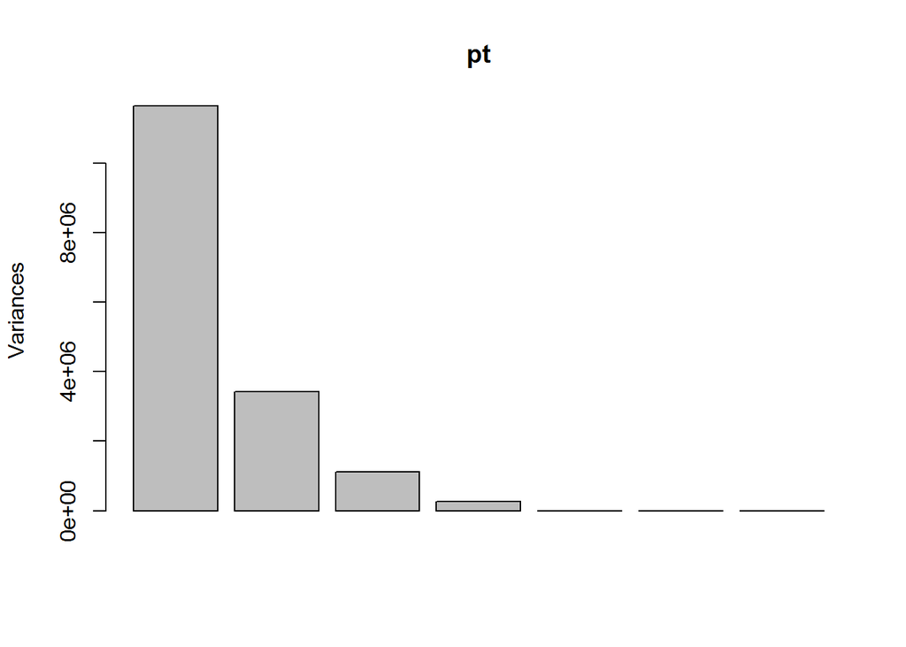

```r
pt<-prcomp(propt)
pz<-prcomp(prop_z)
plot(pt)
```

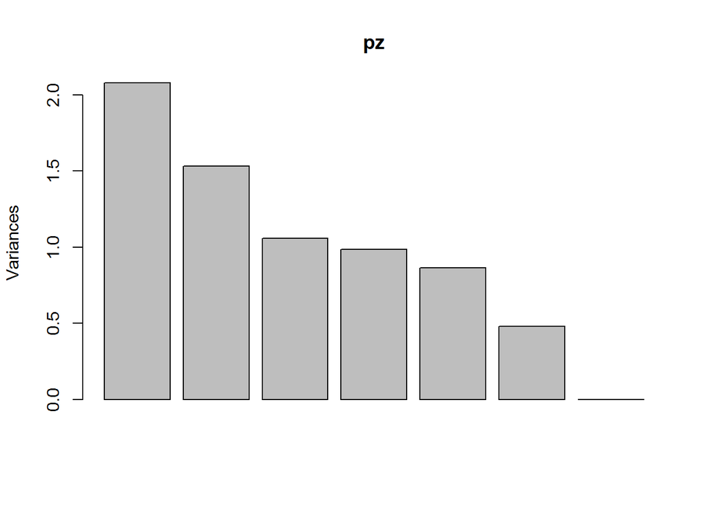

```r
plot(pz)
```

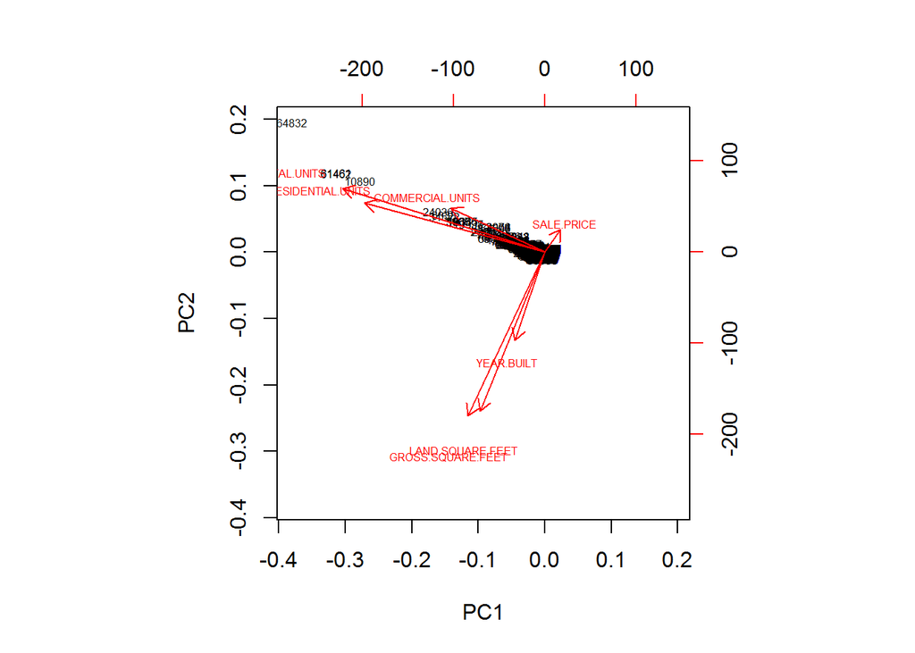

```r
biplot(pz, cex=0.5)
```

Just to verify the biplot, cor() can be used to check.

```r
cor(propt$RESIDENTIAL.UNITS,propt$TOTAL.UNITS)
```

```
## [1] 0.8883087
```

```r
cor(propt$COMMERCIAL.UNITS,propt$TOTAL.UNITS)
```

```
## [1] 0.4729984
```

```r
cor(propt$GROSS.SQUARE.FEET, propt$LAND.SQUARE.FEET)
```

```
## [1] 0.502546
```

```r
cor(prop$YEAR.BUILT, as.numeric(prop$GROSS.SQUARE.FEET))
```

```
## [1] 0.2047544
```

```r
cor(propt$SALE.PRICE, propt$GROSS.SQUARE.FEET)
```

```
## [1] -0.101257
```

```r
cor(propt$TOTAL.UNITS,propt$SALE.PRICE)
```

```
## [1] -0.02414893
```

```r
summary(pz)
```

```
## Importance of components:
##                           PC1    PC2    PC3    PC4    PC5     PC6      PC7
## Standard deviation     1.4422 1.2379 1.0283 0.9924 0.9305 0.69249 0.006523
## Proportion of Variance 0.2971 0.2189 0.1511 0.1407 0.1237 0.06851 0.000010
## Cumulative Proportion  0.2971 0.5161 0.6671 0.8078 0.9315 0.99999 1.000000
```

From summary of principle components, we can conclude that all we need is the four first principle components because these four components themself have wrap 81% of all information from the dataset.

## 3.3 K-Means for Clustering

We are gonna set number of cluster (k) equal to 5.

```r
prop_km <- kmeans(prop_z, 5)
prop$clust <- as.factor(prop_km$cluster)
```

There are several properties from k-means algorithm result, such as: iteration, center, and cluster.

```r
head(prop_km$iter)
```

```
## [1] 5
```

```r
head(prop_km$centers)
```

```
##   RESIDENTIAL.UNITS COMMERCIAL.UNITS  TOTAL.UNITS LAND.SQUARE.FEET
## 1        0.01024571      -0.00164533  0.006653769        0.7153565
## 2       -0.09328314      -0.02045104 -0.090046886       -0.8614694
## 3        0.52055361       0.14660445  0.524375873        0.6760306
## 4       -0.09082768      -0.02162143 -0.087115224       -0.4213369
## 5       -0.01136442      -0.01101969 -0.016752539        0.7755370
##   GROSS.SQUARE.FEET YEAR.BUILT  SALE.PRICE
## 1         0.4249264  0.2765702 -0.97062752
## 2        -0.7134446  0.3231534  0.08617476
## 3         2.3889483  0.2731766 -0.37134644
## 4        -0.7350865 -3.3299333 -0.22150993
## 5         0.2213474  0.2871397  1.05623869
```

```r
head(prop_km$cluster)
```

```
## [1] 3 1 3 3 3 3
```

## 3.4 Combine PCA and K-Means

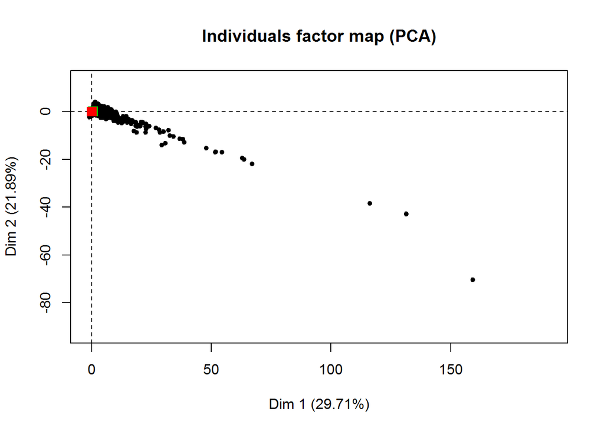

```r
library(FactoMineR)
prop.pca<-PCA(prop_z,graph = F)
plot(prop.pca,choix = "ind",label = "none")
points(prop_km$centers, col=1:3, pch=15, cex=1.5)
```

# 4 Conclusion